# ENV710.002 Applied Statistical Modeling Midterm Exam

Due 27 October 2025 at 11:45 ET

Jiyeong Pyo

#### **Duke Community Standard**

Duke University is a community dedicated to scholarship, leadership, and service and to the principles of honesty, fairness, respect, and accountability. Citizens of this community commit to reflect upon and uphold these principles in all academic and nonacademic endeavors, and to protect and promote a culture of integrity.

#### **The Pledge**

##### Students affirm their commitment to uphold the values of the Duke University community by signing a pledge that states:

#### **To uphold the Duke Community Standard:**

- I will not lie, cheat, or steal in my academic endeavors;
- I will conduct myself responsibly in all my endeavors; and
- I will act if the Standard is compromised.

#### I have adhered to the Duke Community Standard in completing this assignment.

#### Type your name below to state that you adhered to the Duke Community Standard while completing this exam.

Jiyeong Pyo

**1. Histograms (20 points)**

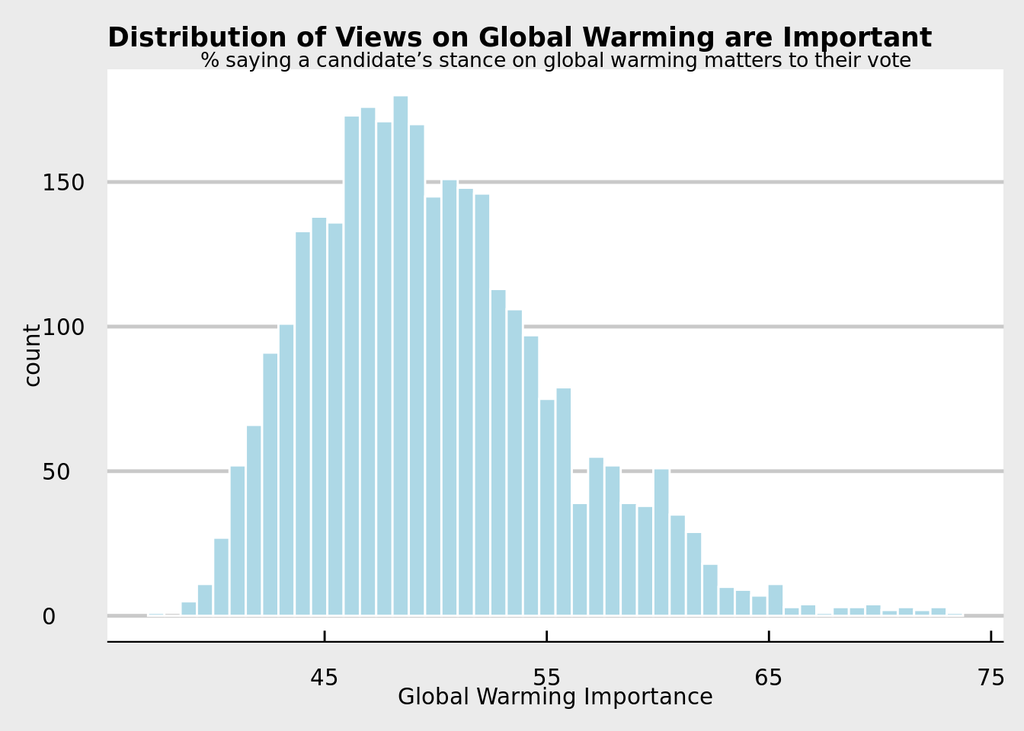

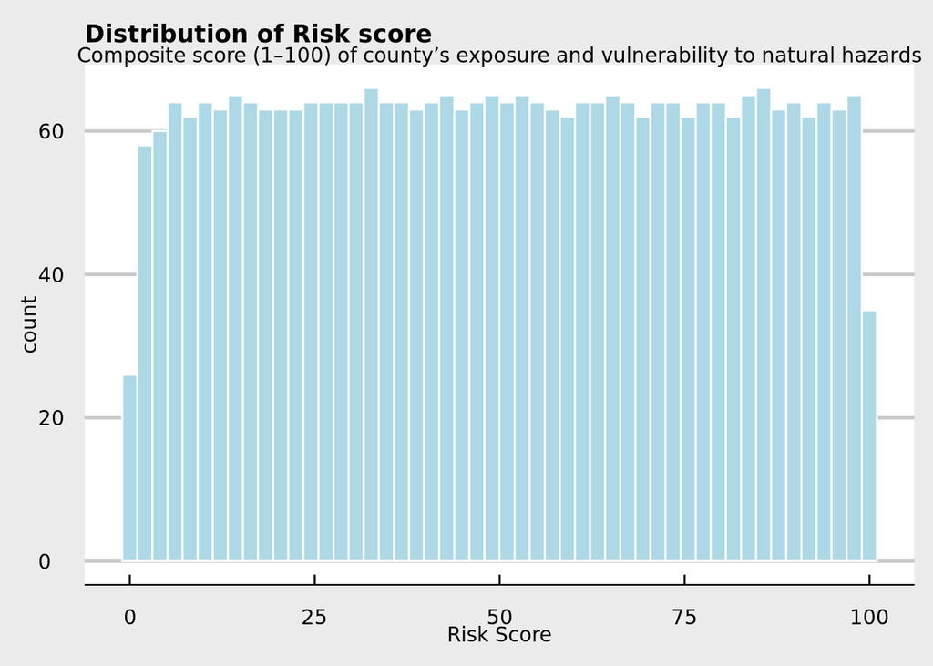

**2. Summary statistics (10 points)**

Summary Statistics

| variable | units | N | Mean | Median | SD | Skewness |
| --- | --- | --- | --- | --- | --- | --- |
| RISK_SCORE | Scale: 1-100 | 3113 | 50.27 | 50.24 | 28.74 | 0.00 |
| gwvoteimp | % | 3113 | 49.96 | 49.21 | 5.60 | 0.75 |

**3. Scatterplots (10 points)**

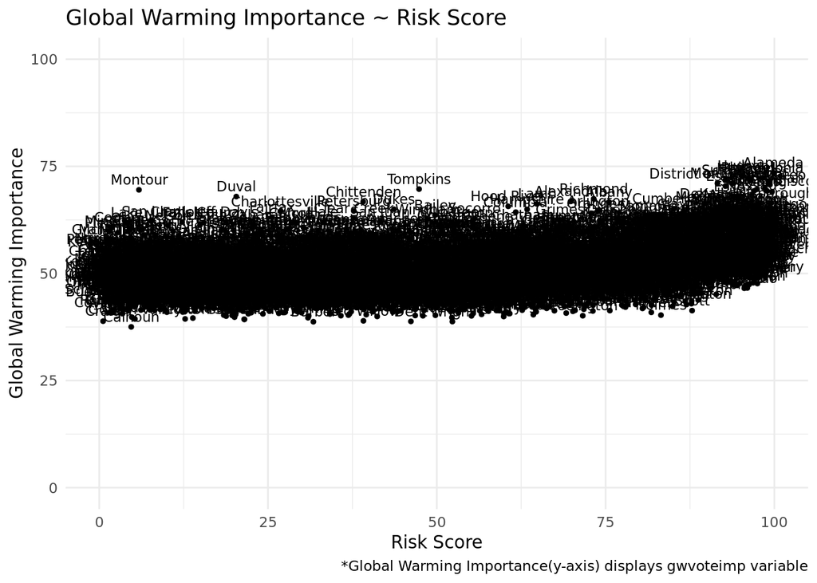

The scatter plot shows that there is slight positive relationship between risk score and global warming importance. The data is evenly distributed so we don’t need to do additional transformation.  
**4. Hypotheses and Model (30 points)**  
The null hypothesis: β₁= 0 : There is no significant difference between risk score and global warming importance. The alternative hypothesis: β₁≠ 0 : There is significant difference between risk score and global warming importance.

```
##
## Call:
## lm(formula = gwvoteimp ~ RISK_SCORE, data = yale)
##
## Residuals:
##     Min      1Q  Median      3Q     Max
## -12.126  -3.727  -0.638   3.107  22.841
##
## Coefficients:
##              Estimate Std. Error t value            Pr(>|t|)
## (Intercept) 46.233064   0.187183  246.99 <0.0000000000000002 ***
## RISK_SCORE   0.074067   0.003233   22.91 <0.0000000000000002 ***
## ---
## Signif. codes:  0 '***' 0.001 '**' 0.01 '*' 0.05 '.' 0.1 ' ' 1
##
## Residual standard error: 5.183 on 3111 degrees of freedom
## Multiple R-squared:  0.1444, Adjusted R-squared:  0.1441
## F-statistic:   525 on 1 and 3111 DF,  p-value: < 0.00000000000000022
```

**5. Model Assumptions (20 points)**

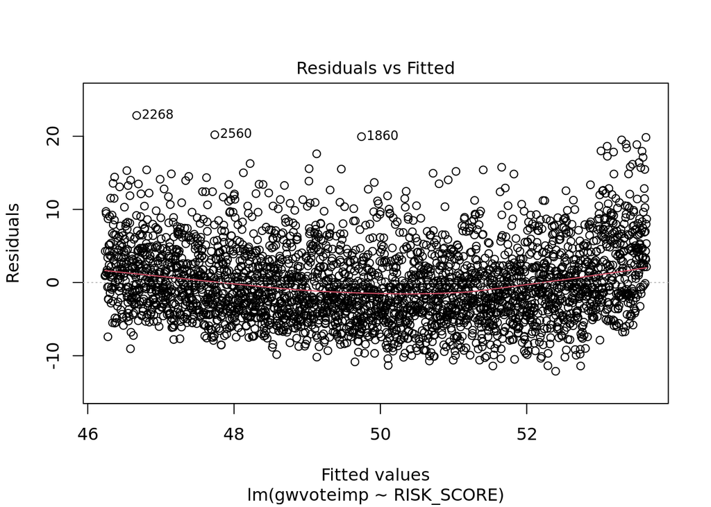

**6. Visualization: Risk across US regions (20 points)**  
The Federal Emergency Management Agency(FEMA) consists of ten regions in the continental United States and territories.The risk score is varied by region.According to the violin plot, each region has different distribution. Especially, region 9 shows that the median of the data is located in the upper part and region 3,8 indicates that the median is located in the lower part. which means that the risk score can be affected by different confounding factors.

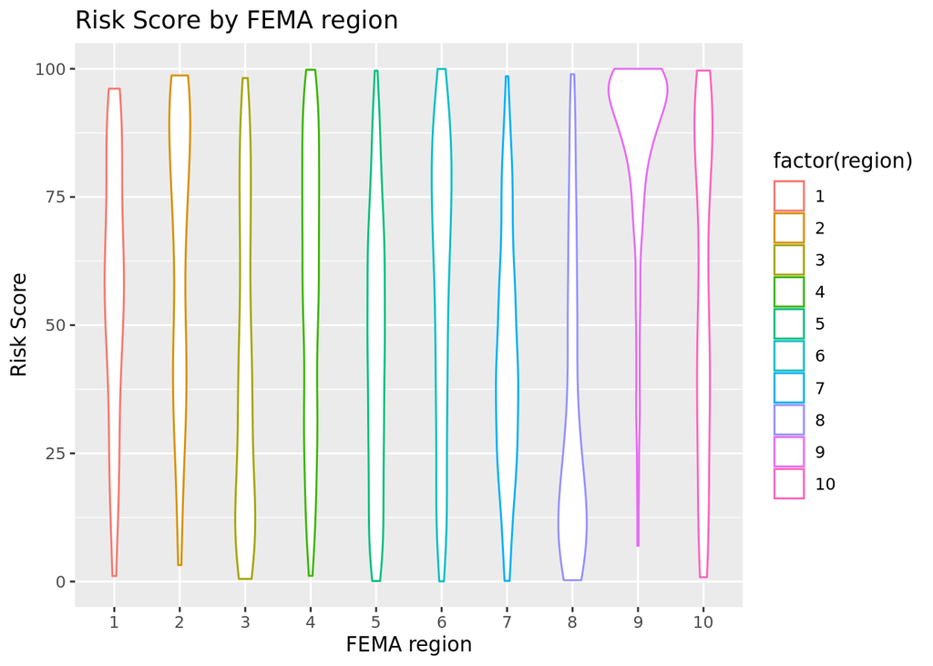

Summary Statistics of Risk Score across Regions

| region | N | Mean | Median | SD | Skewness |
| --- | --- | --- | --- | --- | --- |
| 1 | 54 | 56.97 | 59.42 | 26.05 | -0.32 |
| 2 | 83 | 64.14 | 70.63 | 27.90 | -0.44 |
| 3 | 283 | 40.83 | 36.56 | 29.10 | 0.35 |
| 4 | 735 | 56.28 | 58.32 | 27.17 | -0.20 |
| 5 | 523 | 44.78 | 45.08 | 25.78 | 0.07 |
| 6 | 509 | 56.55 | 61.92 | 27.91 | -0.35 |
| 7 | 412 | 44.02 | 41.78 | 23.57 | 0.26 |
| 8 | 290 | 32.40 | 21.76 | 27.62 | 0.82 |
| 9 | 102 | 84.29 | 91.63 | 19.88 | -1.95 |
| 10 | 122 | 56.10 | 57.13 | 31.72 | -0.20 |

**8. Limitations and Improvements (20 points)**  
The research goal was studying whether individuals who are more directly exposed to the impacts of climate-related hazards—such as flooding, hurricanes, extreme heat, or other forms of environmental disruption—may be more likely to perceive climate change as an urgent problem. The linear model examined the relationship between FEMA’s National Risk Index (RISK_SCORE)—the explanatory variable—and a measure of climate concern. Even though there is statistically positive correlation between two variables, we cannot conclude the climate risk leads to directly perceive climate change as an urgent problem. According to the FEMA regional data, there is a possibility that spacial autocorrelation between region could be generated. For improving the model, we have to conduct multiple regression considering region as a control variable.In addition, this research did not consider the possibility of temporal autocorrelation.For accurate research design, we can do use time series data or using year variable as an control variable for multiple regression.